# class notes11.7

Author

Mio Takata

```r
library(tidyverse)
```

## chi-squared goodness of fit testing

The $\chi^2$ test is used for a single categorical variable. Let’s do an example using `diamonds`.

Suppose we have a sample of size 250 from this set. Is it consistent with the claim that all diamond colors are equally probable.

- $H_0$Null hypothesis: All colors have equal proportions in the equal proportions
- $H_a$Alternative hypothesis: All colors do **not** have equal proportion in the equal proportions

```r
set.seed(0) #we have the same sample going forward
diamond_sample<- diamonds %>%
  slice_sample(n = 250)
```

Next we get a visualization.**bar chart**

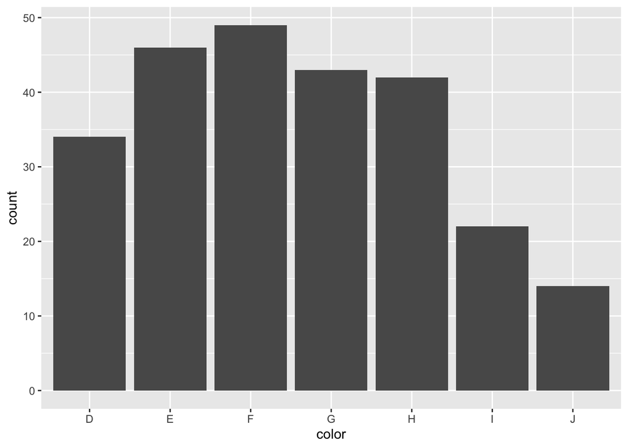

```r
ggplot(diamond_sample, aes(x = color))+
  geom_bar()
```

Looks like the proportions aren’t all the same, but it’s still possible this is just due to chance in the sampling.

First we get the counts for the different factor levels.

```r
t<- table(diamond_sample$color)
t
```

```
 D  E  F  G  H  I  J
34 46 49 43 42 22 14
```

```r
p_null <- rep(1/7, times = 7)
p_null # null hypothesis values
```

```
[1] 0.1428571 0.1428571 0.1428571 0.1428571 0.1428571 0.1428571 0.1428571
```

now we run the test

```r
chisq.test(t, p = p_null)
```

```
    Chi-squared test for given probabilities

data:  t
X-squared = 29.048, df = 6, p-value = 5.958e-05
```

X-squared = 29.048, df = 6, p-value = 5.958e-05

How the observed data is with the null. The p-value measures how consistent our data is with the null. Lower p-value represent strnger evidence against the null.

**A p-value of $5.9*10^{-5}$** represents very strong evidence against the null. We conclude that colors are not equally represented in the population.

## ANOVA

Analysis of variance test whether quantative variable and a categorical variables are independent. $H_0 : \mu_1 = \mu_2 = ...\mu_m$ $H_a : \mu_i \ne \mu_j$ for some i and j

The fundamental idea of ANOVA is to compare the variablitity of the data whtin the groups to varibility between groups. - how different means do they have - how much variablity within the groups exist?

## From the video

ANOVA is used to test whether quantitative variable and categorical variables are indepdennt, meaning that if the means are all the same, it is independent

f raito is the probability distribution of f statistics when the null hypothesis is true

## post hoc test

- Tukey honest significant differences test where mutltiple t-tests between groups are pefromed. It limites the total probability of a type 1 error by demanding smaller p values

```r
penguins <- penguins %>%
  glimpse()
```

```
Rows: 344
Columns: 8
$ species     <fct> Adelie, Adelie, Adelie, Adelie, Adelie, Adelie, Adelie, Ad…
$ island      <fct> Torgersen, Torgersen, Torgersen, Torgersen, Torgersen, Tor…
$ bill_len    <dbl> 39.1, 39.5, 40.3, NA, 36.7, 39.3, 38.9, 39.2, 34.1, 42.0, …
$ bill_dep    <dbl> 18.7, 17.4, 18.0, NA, 19.3, 20.6, 17.8, 19.6, 18.1, 20.2, …
$ flipper_len <int> 181, 186, 195, NA, 193, 190, 181, 195, 193, 190, 186, 180,…
$ body_mass   <int> 3750, 3800, 3250, NA, 3450, 3650, 3625, 4675, 3475, 4250, …
$ sex         <fct> male, female, female, NA, female, male, female, male, NA, …
$ year        <int> 2007, 2007, 2007, 2007, 2007, 2007, 2007, 2007, 2007, 2007…
```

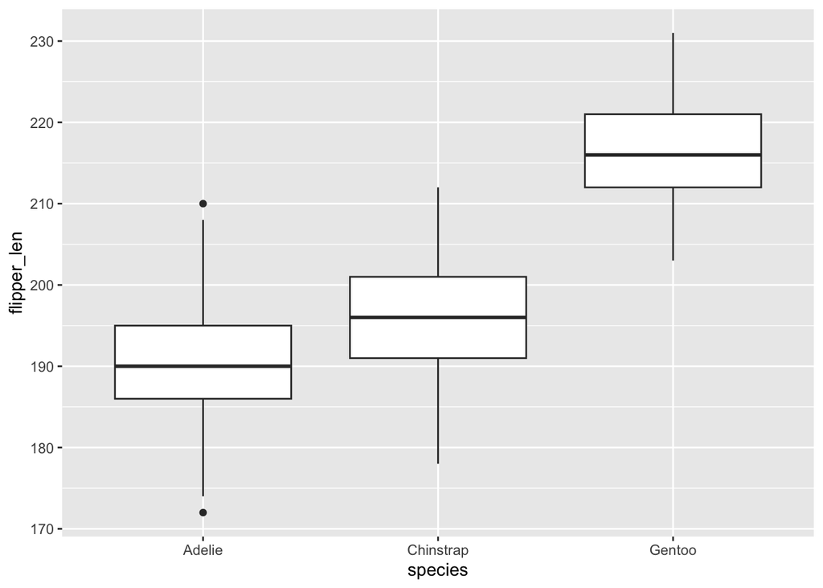

```r
ggplot(penguins, aes(x = species, y = flipper_len))+
         geom_boxplot()
```

## Does species help explain flipper length?

we’re looking at indevidual penguins, so it is reasonable to assume that those observations are independent. Also, it looks like nomarlly distributed and the length of the boxes are similar, which means that the variances are also the same.

## Histgram

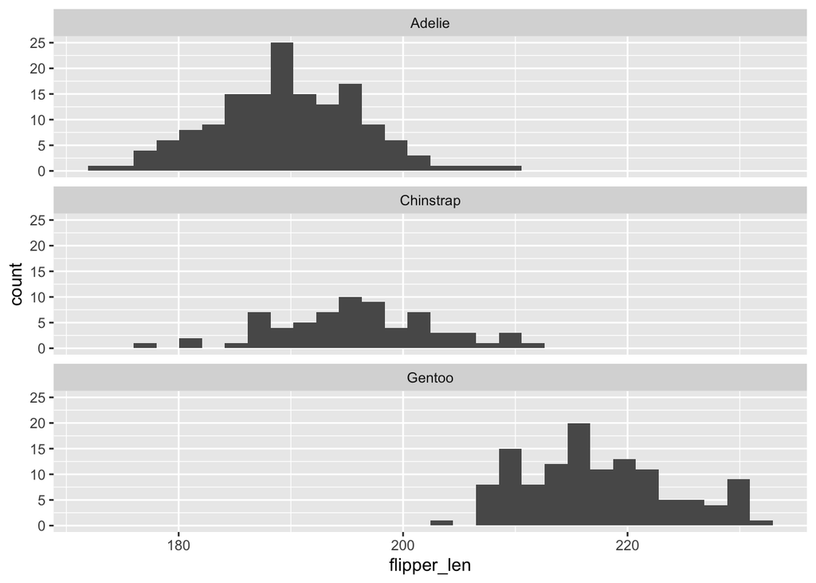

```r
ggplot(penguins, aes(x = flipper_len))+
  geom_histogram()+
  facet_wrap(~species, ncol = 1)
```

All of the histogram looks normally distributed.

```r
penguins %>%
  group_by(species) %>%
  summarize(var(flipper_len, na.rm = TRUE))
```

```
# A tibble: 3 × 2
  species   `var(flipper_len, na.rm = TRUE)`
  <fct>                                <dbl>
1 Adelie                                42.8
2 Chinstrap                             50.9
3 Gentoo                                42.1
```

# Performing ANOVA, ANOVA table

```r
model<- aov(flipper_len ~ species, data = penguins)
summary(model)
```

```
             Df Sum Sq Mean Sq F value Pr(>F)
species       2  52473   26237   594.8 <2e-16 ***
Residuals   339  14953      44
---
Signif. codes:  0 '***' 0.001 '**' 0.01 '*' 0.05 '.' 0.1 ' ' 1
2 observations deleted due to missingness
```

Small pvalues shows strong evidnce against the null hypothesis of those two variables are independent

```r
TukeyHSD(model)
```

```
  Tukey multiple comparisons of means
    95% family-wise confidence level

Fit: aov(formula = flipper_len ~ species, data = penguins)

$species
                      diff       lwr       upr p adj
Chinstrap-Adelie  5.869887  3.586583  8.153191     0
Gentoo-Adelie    27.233349 25.334376 29.132323     0
Gentoo-Chinstrap 21.363462 19.000841 23.726084     0
```

Low p values between each variables show that there is a difference between every varibale.